# Lab 4 Demo

2024-04-22

This data set includes more possible predictors than the text alone, but for this model we will only use the text variable

```r
urlfile ="https://raw.githubusercontent.com/MaRo406/EDS-231-text-sentiment/main/data/climbing_reports_model_dat.csv"
incidents_df<-readr::read_csv(url(urlfile))
```

Now we’ll split our data into training and test portions

```r
set.seed(1234)

incidents2class <- incidents_df %>%
  mutate(fatal = factor(ifelse(is.na(Deadly), "non-fatal", "fatal")))

incidents_split <- initial_split(incidents2class, strata = fatal) # strata addresses class                                                                            imbalance

incidents_train <- training(incidents_split)
incidents_test <- testing(incidents_split)
```

We use recipe() to specify the predictor and outcome variables and the data.

```r
incidents_rec <-recipe(fatal ~ Text, data = incidents_train)
```

Next we add some familiar pre-processing steps on our Text variable: tokenize to word level, filter to the most common words, and calculate tf-idf.

```r
recipe <- incidents_rec %>%
  step_tokenize(Text) %>%
  step_tokenfilter(Text, max_tokens = 1000) %>%
  step_tfidf(Text)
```

Create tidymodels workflow to combine the modeling components

```r
incidents_wf <- workflow() %>%
  add_recipe(recipe)
```

```r
nb_spec <- naive_Bayes() %>%
  set_mode("classification") %>%
  set_engine("naivebayes")
```

Now we are ready to add our model to the workflow and fit it to the training data

```r
nb_fit <- incidents_wf %>%
  add_model(nb_spec) %>%
  fit(data = incidents_train)
```

Next up is model evaluation. We’ll stretch our training data further and use resampling to evaluate our naive Bayes model. Here we create 10-fold cross-validation sets, and use them to estimate performance.

```r
set.seed(650)
incidents_folds <- vfold_cv(incidents_train)
```

```r
nb_wf <- workflow() %>%
  add_recipe(recipe) %>%
  add_model(nb_spec)
```

To estimate its performance, we fit the model to each of the resampled folds, and then evaluate on the heldout part of each resampled fold.

```r
nb_rs <- fit_resamples(
  nb_wf,
  incidents_folds,
  control = control_resamples(save_pred=T))
```

```r
nb_rs_metrics <- collect_metrics(nb_rs)

nb_rs_predictions <- collect_predictions(nb_rs)
```

We’ll use two performance metrics: accuracy and ROC AUC. Accuracy is the proportion of the data that is predicted correctly. The ROC curve plots the true positive rate against the false positive rate; AUC closer to 1 indicates a better-performing model, while AUC closer to 0.5 indicates a model that does no better than random guessing.

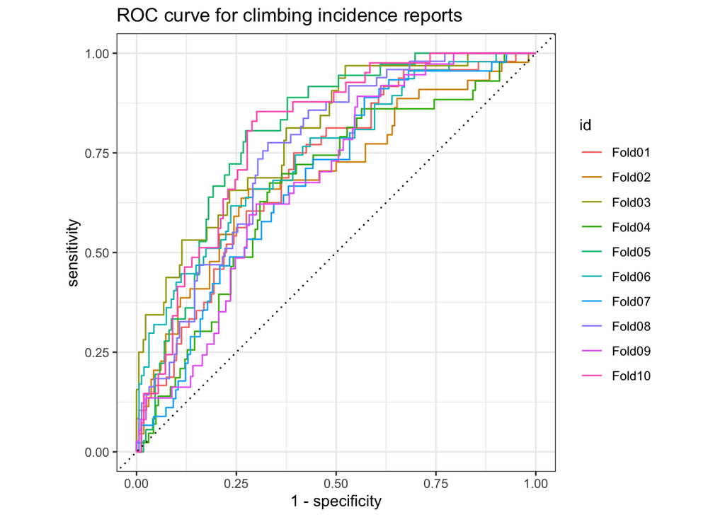

```r
nb_rs_predictions %>%
  group_by(id) %>%
  roc_curve(truth=fatal, .pred_fatal) %>%
  autoplot() +
  labs(title="ROC curve for climbing incidence reports")
```

Another model method involves the confusion matrix. A confusion matrix tabulates a model’s false positives and false negatives for each class.

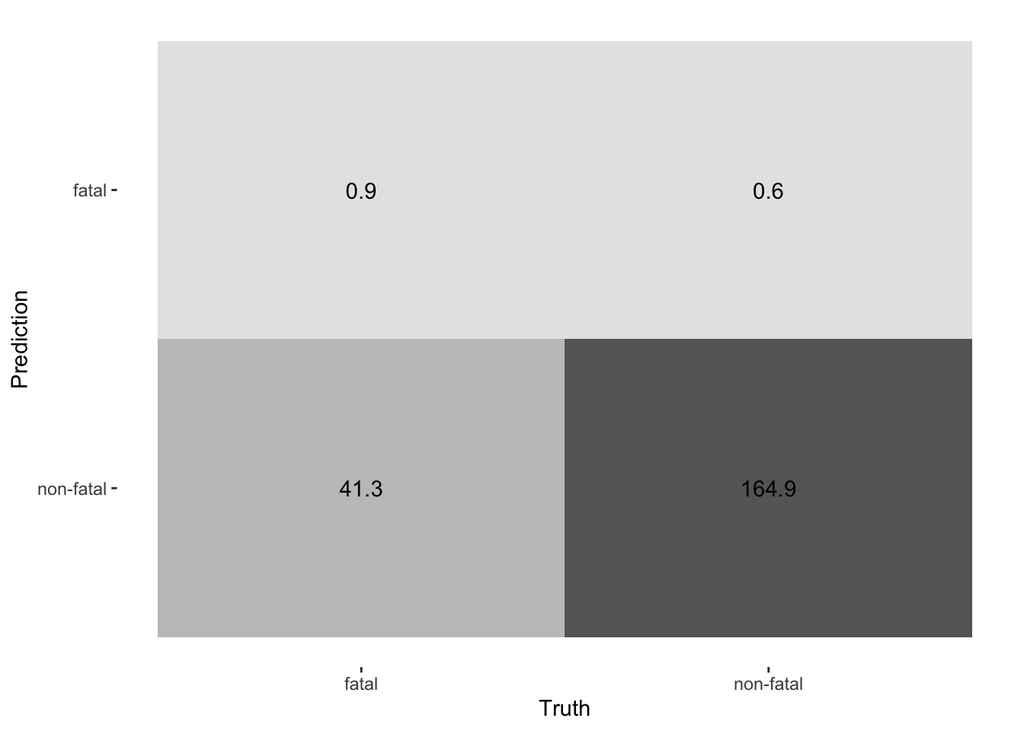

```r
conf_mat_resampled(nb_rs, tidy=F) %>%
  autoplot(type="heatmap")
```